# Pilot Replication Analyses

# Confirming target-level threat factor

## Correlation matrix

```r
cfa_vars <- clean_data_bfi %>%
  select(sub_id, distance_coffee, distance_town, realistic_q,
         symbolic_q, explicit_targ, explicit_group) %>%
  unique() %>%
  na.omit() %>%
  select(distance_coffee, distance_town, realistic_q,
         symbolic_q, explicit_targ, explicit_group)

cor_df <- cfa_vars %>%
  rename("Distance: Coffee" = distance_coffee,
         "Distance: Town" = distance_town,
         "Realistic" = realistic_q,
         "Symbolic" = symbolic_q,
         "Explicit: Target" = explicit_targ,
         "Explicit: Group" = explicit_group)


cor_matrix_cfa <- cor(cor_df)
cor_matrix_cfa
```

```
##                  Distance: Coffee Distance: Town Realistic  Symbolic
## Distance: Coffee        1.0000000      0.2299566 0.3481300 0.2883987
## Distance: Town          0.2299566      1.0000000 0.2466537 0.2260321
## Realistic               0.3481300      0.2466537 1.0000000 0.8259370
## Symbolic                0.2883987      0.2260321 0.8259370 1.0000000
## Explicit: Target        0.3120700      0.2342765 0.7593413 0.7110046
## Explicit: Group         0.2609902      0.1623220 0.3245295 0.3249814
##                  Explicit: Target Explicit: Group
## Distance: Coffee        0.3120700       0.2609902
## Distance: Town          0.2342765       0.1623220
## Realistic               0.7593413       0.3245295
## Symbolic                0.7110046       0.3249814
## Explicit: Target        1.0000000       0.4946657
## Explicit: Group         0.4946657       1.0000000
```

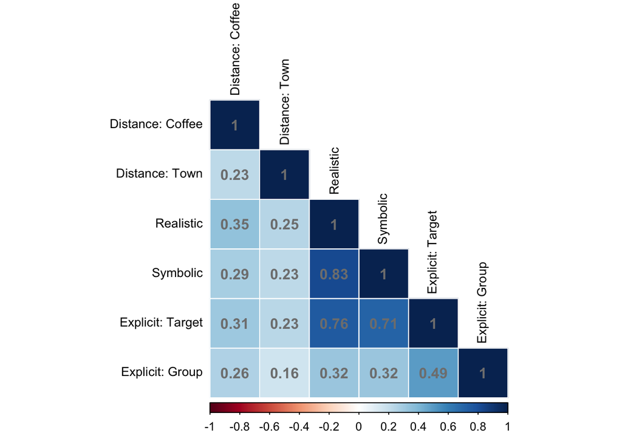

```r
corrplot(cor_matrix_cfa,
         is.corr = TRUE,
         #method = "number",
         method = 'color',
         tl.cex = .85,
         tl.col = 'black',
         addgrid.col = 'white',
         addCoef.col = 'grey50',
         type = 'lower')
```

*This corresponds to factorability, an assumption of Factor Analysis*

The results are consistent with the Pilot Analysis - symbolic and realistic are highly correlated to one another and highly correlated with target-level explicit threat, but not group-level explicit threat. Validates that symbolic and realistic threat are measuring target-level threat, and that these measures differ from implicit measures of physical distancing.

## CFA Model (As pre-registered)

### 2 indicators

```r
cfa_vars_2 <- cfa_vars %>%
  select(realistic_q, symbolic_q)

cfa_mod_2  <- 'target_threat  =~ symbolic_q + realistic_q'

onefac_cfa2 <- cfa(cfa_mod_2, data = cfa_vars_2)

summary(onefac_cfa2)
```

```
## lavaan 0.6-11 ended normally after 16 iterations
##
##   Estimator                                         ML
##   Optimization method                           NLMINB
##   Number of model parameters                         4
##
##   Number of observations                           424
##
## Model Test User Model:
##
##   Test statistic                                    NA
##   Degrees of freedom                                -1
##   P-value (Unknown)                                 NA
##
## Parameter Estimates:
##
##   Standard errors                             Standard
##   Information                                 Expected
##   Information saturated (h1) model          Structured
##
## Latent Variables:
##                    Estimate  Std.Err  z-value  P(>|z|)
##   target_threat =~
##     symbolic_q        1.000
##     realistic_q       0.963       NA
##
## Variances:
##                    Estimate  Std.Err  z-value  P(>|z|)
##    .symbolic_q        0.256       NA
##    .realistic_q       0.184       NA
##     target_threat     1.075       NA
```

Not identifiable

### 3 Indicators

```r
cfa_vars_3 <- cfa_vars %>%
  select(symbolic_q, realistic_q, explicit_targ)

cfa_mod_3  <- 'target_threat  =~ symbolic_q + realistic_q + explicit_targ'

onefac_cfa3 <- cfa(cfa_mod_3, data = cfa_vars_3)

summary(onefac_cfa3)
```

```
## lavaan 0.6-11 ended normally after 17 iterations
##
##   Estimator                                         ML
##   Optimization method                           NLMINB
##   Number of model parameters                         6
##
##   Number of observations                           424
##
## Model Test User Model:
##
##   Test statistic                                 0.000
##   Degrees of freedom                                 0
##
## Parameter Estimates:
##
##   Standard errors                             Standard
##   Information                                 Expected
##   Information saturated (h1) model          Structured
##
## Latent Variables:
##                    Estimate  Std.Err  z-value  P(>|z|)
##   target_threat =~
##     symbolic_q        1.000
##     realistic_q       1.007    0.039   25.485    0.000
##     explicit_targ     0.894    0.042   21.319    0.000
##
## Variances:
##                    Estimate  Std.Err  z-value  P(>|z|)
##    .symbolic_q        0.302    0.033    9.128    0.000
##    .realistic_q       0.139    0.028    5.017    0.000
##    .explicit_targ     0.436    0.036   11.999    0.000
##     target_threat     1.029    0.093   11.106    0.000
```

Might not be the correct analysis due to small number of indicators

## EFA

### nfactors

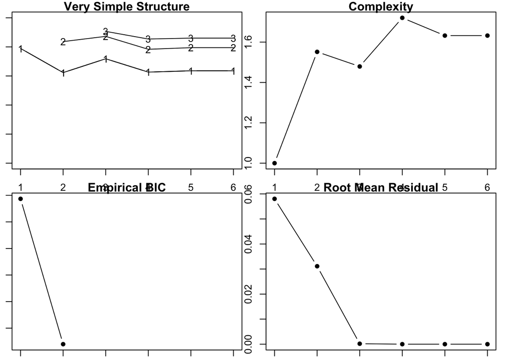

```
##
## Number of factors
## Call: vss(x = x, n = n, rotate = rotate, diagonal = diagonal, fm = fm,
##     n.obs = n.obs, plot = FALSE, title = title, use = use, cor = cor)
## VSS complexity 1 achieves a maximimum of 0.79  with  1  factors
## VSS complexity 2 achieves a maximimum of 0.87  with  3  factors
## The Velicer MAP achieves a minimum of 0.08  with  1  factors
## Empirical BIC achieves a minimum of  -11.88  with  2  factors
## Sample Size adjusted BIC achieves a minimum of  2.39  with  2  factors
##
## Statistics by number of factors
##   vss1 vss2   map dof         chisq                prob sqresid  fit RMSEA BIC
## 1 0.79 0.00 0.076   9 94.0025140296 0.00000000000000026     2.5 0.79 0.149  40
## 2 0.62 0.84 0.139   4 13.8932818131 0.00764356168997043     1.9 0.84 0.076 -10
## 3 0.72 0.87 0.264   0  0.0015288056                  NA     1.1 0.91    NA  NA
## 4 0.63 0.78 0.426  -3  0.0000000057                  NA     1.4 0.88    NA  NA
## 5 0.64 0.79 1.000  -5  0.0000000000                  NA     1.4 0.88    NA  NA
## 6 0.64 0.79    NA  -6  0.0000000000                  NA     1.4 0.88    NA  NA
##   SABIC complex             eChisq         SRMR eCRMS eBIC
## 1  68.1     1.0 42.841008550530965 0.0580345054 0.075  -12
## 2   2.4     1.6 12.318808756038793 0.0311200869 0.060  -12
## 3    NA     1.5  0.000406103727048 0.0001786796    NA   NA
## 4    NA     1.7  0.000000000928065 0.0000002701    NA   NA
## 5    NA     1.6  0.000000000000044 0.0000000019    NA   NA
## 6    NA     1.6  0.000000000000044 0.0000000019    NA   NA
```

```r
par(mar=c(1,1,1,1))
nfactors(cfa_vars)
```

### 1 Factor EFA

```r
efa_replication <- cfa_vars %>%
  select(realistic_q, symbolic_q, distance_coffee, distance_town)

efa_1fac <- psych::fa(efa_replication, nfactors = 1)

efa_1fac %>%
  model_parameters(sort = TRUE, threshold = "max")
```

```
## # Rotated loadings from Factor Analysis (oblimin-rotation)
##
## Variable        | MR1  | Complexity | Uniqueness
## ------------------------------------------------
## realistic_q     | 0.96 |    1.00    |    0.08
## symbolic_q      | 0.84 |    1.00    |    0.29
## distance_coffee | 0.38 |    1.00    |    0.86
## distance_town   | 0.29 |    1.00    |    0.92
##
## The unique latent factor (oblimin rotation) accounted for 46.44% of the total variance of the original data.
```

Replicating the pilot, realistic and symbolic have high loadings, while the distance measuries have low loadings and high uniqueness. This corresponds with the plots from nfactors that show that at most there could be two latent variables and, when forced to one, only symbolic and realistic load reliably into the one factor.

## Alpha: Realistic and Symbolic

```r
efa_vars_2 <- cfa_vars %>%
  select(symbolic_q, realistic_q)

psych::alpha(efa_vars_2)
```

```
##
## Reliability analysis
## Call: psych::alpha(x = efa_vars_2)
##
##   raw_alpha std.alpha G6(smc) average_r S/N    ase mean  sd median_r
##        0.9       0.9    0.83      0.83 9.5 0.0093  2.7 1.1     0.83
##
##     95% confidence boundaries
##          lower alpha upper
## Feldt     0.88   0.9  0.92
## Duhachek  0.89   0.9  0.92
##
##  Reliability if an item is dropped:
##             raw_alpha std.alpha G6(smc) average_r S/N alpha se var.r med.r
## symbolic_q       0.88      0.83    0.68      0.83 4.7       NA     0  0.83
## realistic_q      0.78      0.83    0.68      0.83 4.7       NA     0  0.83
##
##  Item statistics
##               n raw.r std.r r.cor r.drop mean  sd
## symbolic_q  424  0.96  0.96  0.87   0.83  2.6 1.2
## realistic_q 424  0.95  0.96  0.87   0.83  2.8 1.1
##
## Non missing response frequency for each item
##                1   2    3    4 miss
## symbolic_q  0.24 0.2 0.25 0.30    0
## realistic_q 0.18 0.2 0.30 0.32    0
```

## Composite target-level threat measure

*Combining realistic and symbolic threat into one measure, like in the pilot.*

```r
# Add to both the eli and bfi datasets
clean_data_bfi %<>%
  mutate(itt_comp = rowMeans(select(., c("realistic_q", "symbolic_q"))))

clean_data_eli %<>%
  mutate(itt_comp = rowMeans(select(., c("realistic_q", "symbolic_q"))))
```

### Mean

```r
# for these analyses, only need to use one dataset - default to bfi
mean(clean_data_bfi$itt_comp)
```

```
## [1] 2.692217
```

### SD

```r
sd(clean_data_bfi$itt_comp)
```

```
## [1] 1.070779
```

### Range

```r
range(clean_data_bfi$itt_comp)
```

```
## [1] 1 4
```

# ANOVA

## Summary results

```r
# getting data for the anova at the subject level; as the data was in long format at the item level, selected variables and did unique to get the correct length for the subject level
anova_data <- clean_data_bfi %>%
  select(itt_comp, target_condition, sub_id) %>%
  unique()

# Re-arranging so contrasts compare to control as reference
anova_data %<>%
  mutate(target_condition = forcats::fct_relevel(target_condition, c("CONTROL", "WARM", "LOSS")))
contrasts(anova_data$target_condition)
```

```
##         WARM LOSS
## CONTROL    0    0
## WARM       1    0
## LOSS       0    1
```

```r
results <- aov(itt_comp ~ target_condition, data = anova_data)
summary(results)
```

```
##                   Df Sum Sq Mean Sq F value              Pr(>F)
## target_condition   2  236.8  118.42     200 <0.0000000000000002 ***
## Residuals        421  249.2    0.59
## ---
## Signif. codes:  0 '***' 0.001 '**' 0.01 '*' 0.05 '.' 0.1 ' ' 1
```

#### Residuals & Heteroscedastisticity

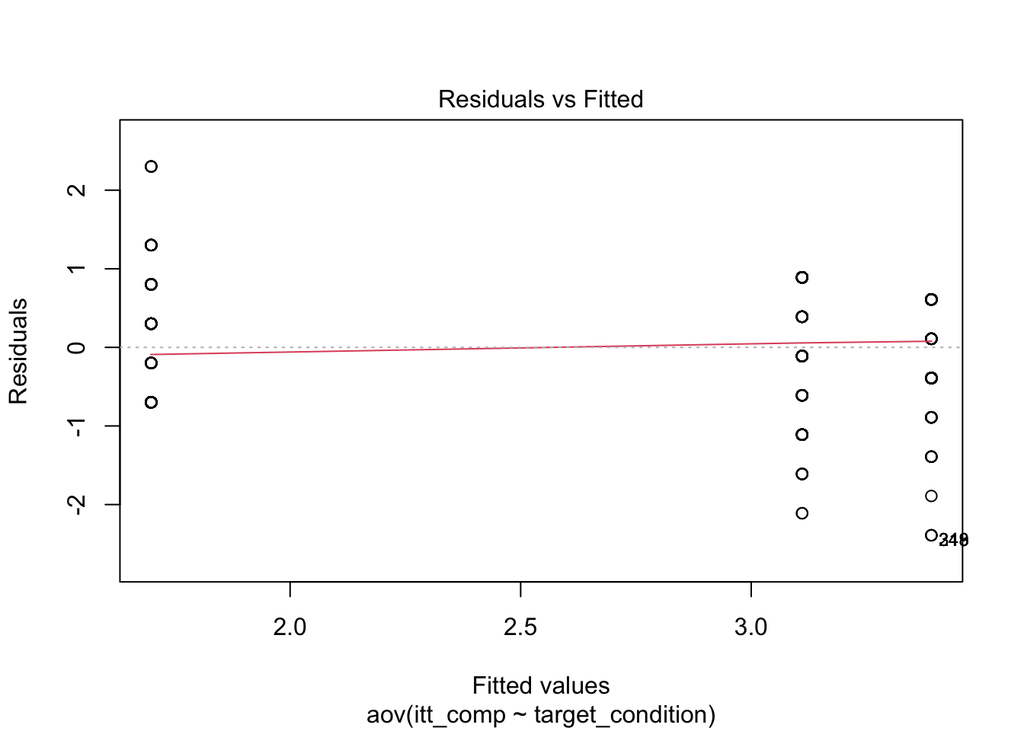

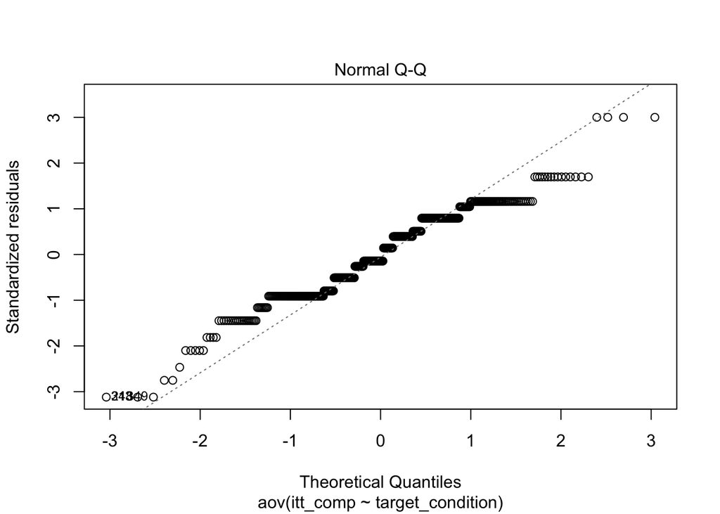

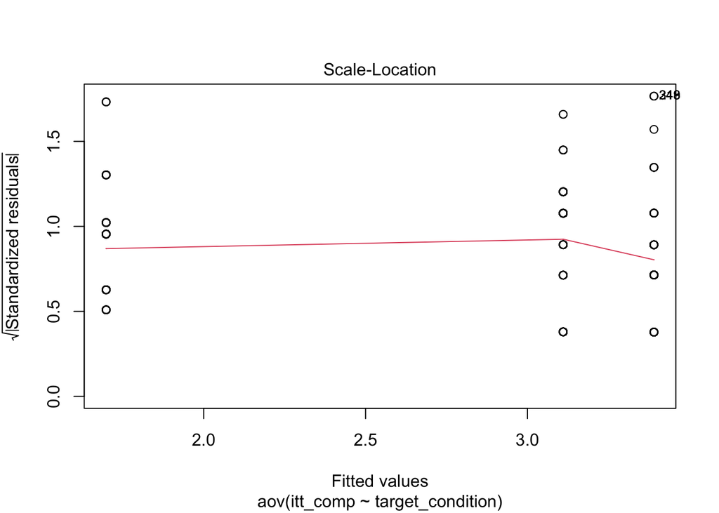

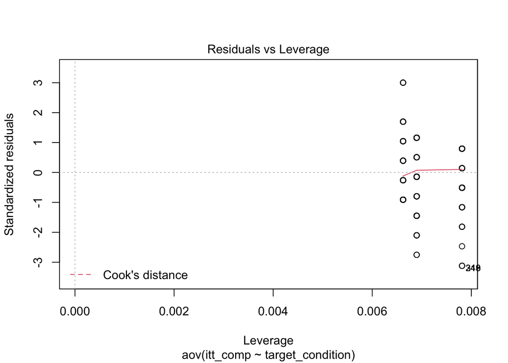

```r
plot(results)
```

A little weird, but working with categorical variables. The QQ especially suggests some non-normality of residuals, but regression models are robust to violations of normality and heteroscedastisticity.

#### Post-hoc test

```r
emmeans(results, pairwise ~ target_condition)
```

```
## $emmeans
##  target_condition emmean     SE  df lower.CL upper.CL
##  CONTROL            1.70 0.0626 421     1.58     1.82
##  WARM               3.11 0.0639 421     2.98     3.24
##  LOSS               3.39 0.0680 421     3.26     3.52
##
## Confidence level used: 0.95
##
## $contrasts
##  contrast       estimate     SE  df t.ratio p.value
##  CONTROL - WARM    -1.41 0.0895 421 -15.779  <.0001
##  CONTROL - LOSS    -1.69 0.0924 421 -18.302  <.0001
##  WARM - LOSS       -0.28 0.0933 421  -3.004  0.0079
##
## P value adjustment: tukey method for comparing a family of 3 estimates
```

The loss target results in the the most threat, which is significantly higher than both the warm and control conditions. The control condition results in the least threat, which is significantly lower than the warm condition. This replicates the pilot study.